# Week 12: Flexible Regression - Part 3

PS 818 - Statistical Models

Anton Strezhnev

strezhnev@wisc.edu

University of Wisconsin-Madison

November 17, 2025

$$\require{cancel}
\DeclareMathOperator*{\argmin}{arg\,min}$$

$$\DeclareMathOperator*{\argmax}{arg\,max}$$

# Previously

$$\DeclareMathOperator*{\argmax}{arg\,max}$$

- **Kernels**
  - “Kernel smoothing” - Kernels as a “localization” tool
  - “Kernel methods” - Kernels as regression inputs
  - Two *different* uses of the term/concept - but some interesting relations
- **Forests**
  - Tree-based models for classification and regression
  - Ensembles/averages of trees via **random forests**

# This week

- **More forests**
  - Other methods of aggregating trees - **Bayesian Additive Regression Trees**
  - Trees for detecting causal heterogeneity
  - “Honest” inference via sample-splitting
- **More kernels**
  - Model-based interpretation via **gaussian processes**

# Classification and Regression Trees (CART)

- The **CART** algorithm constructs a **prediction** for an outcome $Y$ given some inputs $X$ by **partitioning** the space of $X$ into a series of $M$ **hyper-rectangles**
  - Introduced by **Breiman et. al. (1984)**
  - Very good political science summary in **Montgomery and Olivella (2018)**
- We’ll define a **tree**-based prediction as:

$$f(X) = T(X, \theta) = \sum_{m=1}^M c_m \mathbf{I}(X \in R_m)$$

- Here $\theta$ denotes the tree-specific “hyperparameters” (e.g. tree-depth, node size, etc…)

# Classification and Regression Trees (CART)

- Searching over the space of all possible splits and all possible covariates to minimize some error function is **computationally prohibitive**
- Basic **recursive binary partitioning** algorithm:
  - (1): For each variable, find a splitting point that minimizes the **within-partition** variance
  - (2): Split on the single variable that provides the **best split** among these variables
  - (3): Repeat 1/2 on each **sub-sample** created by the previous split.
  - (4): Stop if some stopping rule reached (e.g. minimum node size).
- **Prune** the tree to remove splits that have a minimal impact on fit

# Example: Transgender attitudes (Broockman and Kalla, 2016)

- **Broockman and Kalla (2016)** study the effect of in-person canvassing on attitudes towards transgender individuals.
  - We’ll get to the experiment later, but first we’ll model attitudes at baseline using available covariates.
- The study started by recruiting about 68,000 respondents for a baseline intake survey

```r
canvas <- read_dta("data/broockman_kalla_replication_data.dta")
```

- It then randomly selected 1,825 to be assigned to receive either of the two canvassing conditions.

```r
canvas_exp <- canvas %>% filter(!is.na(treat_ind))
canvas_exp <- canvas %>% filter(!is.na(vf_age)&!is.na(vf_republican)&!is.na(vf_democrat)&!is.na(vf_female)&!is.na(vf_hispanic)&
                        !is.na(religious_t0)&!is.na(ssm_t0)&!is.na(ideology_t0))
```

# Example: Transgender attitudes

- The main outcome of interest is `therm_trans_t0`, a 0-100 attitude thermometer measured at baseline.

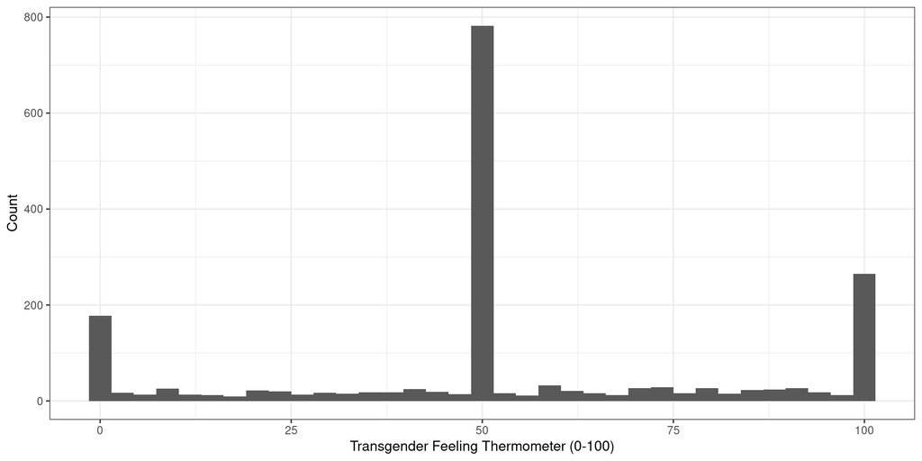

# Example: Transgender attitudes

- We have some covariates observed in the voter file as well as a number of questions asked on the survey

```r
predict_tree <- rpart(therm_trans_t0 ~ vf_age + vf_republican + vf_democrat + vf_female + vf_hispanic + vf_black +
                        religious_t0 + ssm_t0 + ideology_t0,
                  data = canvas_exp)
```

# Example: Transgender attitudes

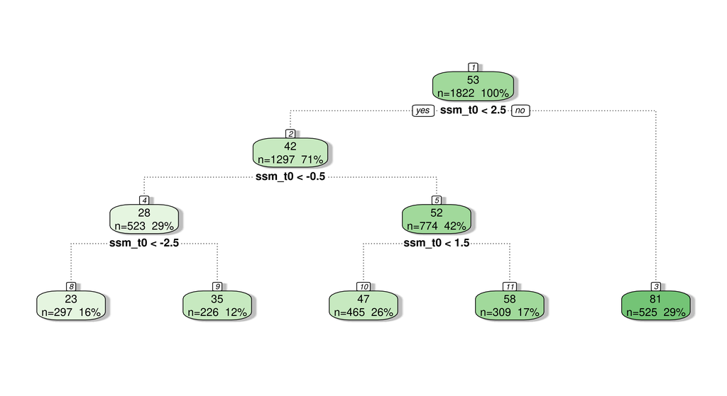

# Example: Transgender attitudes

- What happens if we lower the “complexity parameter” required to even consider a split

```r
predict_tree_moresplits <- rpart(therm_trans_t0 ~ vf_age + vf_republican + vf_democrat + vf_female + vf_hispanic + vf_black +
                        religious_t0 + ssm_t0 + ideology_t0,
                  data = canvas_exp, control = rpart.control(cp=0.005))
```

```r
plotcp(predict_tree_moresplits)
```

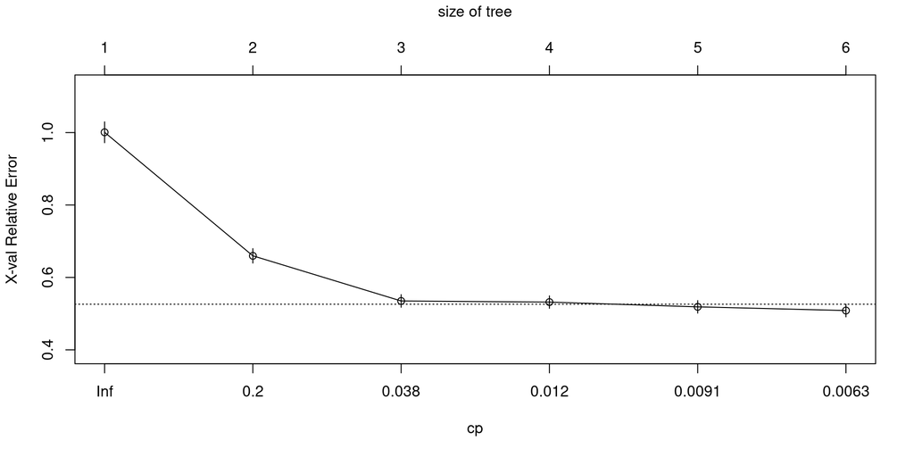

# Example: Transgender attitudes

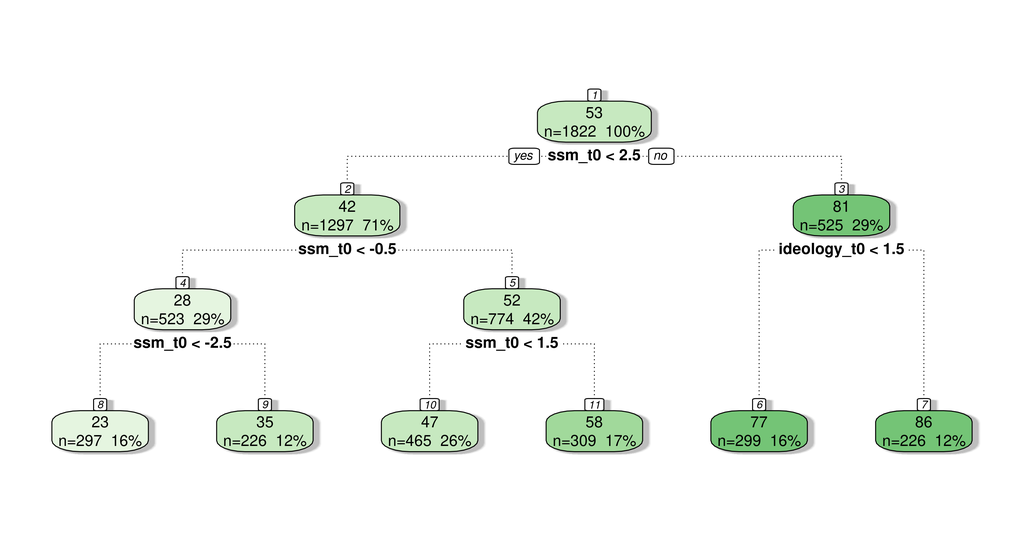

# Example: Transgender attitudes

- Turns out attitudes on same-sex marriage are **extremely** predictive. What if we took out that input?

```r
predict_tree2 <- rpart(therm_trans_t0 ~ vf_age + vf_republican + vf_democrat + vf_female + vf_hispanic +
                        religious_t0 + ideology_t0,
                  data = canvas_exp)
```

# Example: Transgender attitudes

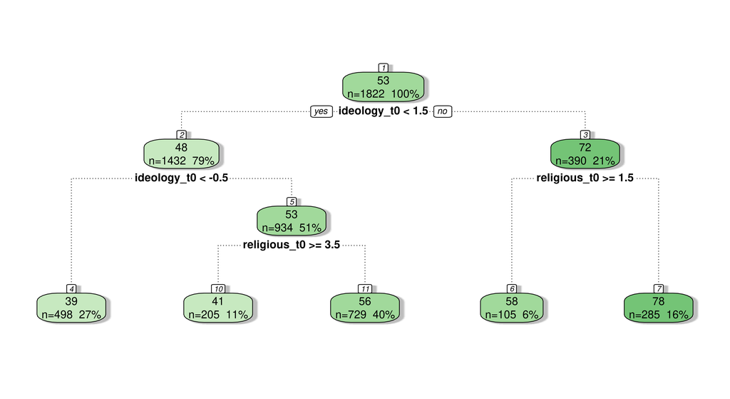

# Example: Transgender Attitudes

- Lastly, what about just the voter file covariates

```r
predict_tree3 <- rpart(therm_trans_t0 ~ vf_age + vf_republican + vf_democrat + vf_female + vf_hispanic,
                  data = canvas_exp)
```

# Example: Transgender attitudes

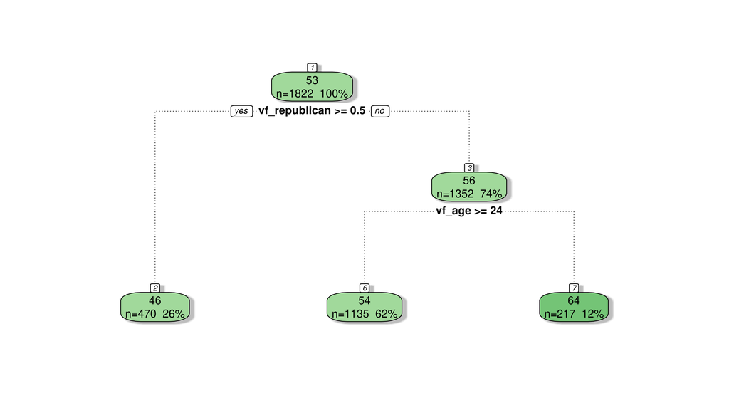

# Combining trees

- The problem with a **single tree** is that it’s still highly likely to overfit the data even with pruning and cross-validation.
- **Solution**: Grow many trees and combine them

  $$f(X) = \sum_{k=1}^K T_k(X, \theta_k)$$
- But lots of different approaches to **combination**:
  - **Random forests**
  - **Gradient Boosting**
  - **Bayesian Additive Regression Trees**

# Random forests

- The **easiest** way to aggregate is to simply average over a bunch of trees grown in different ways
  - Best aggregation comes from having **independent** trees
- **Breiman (2001)** Random Forest algorithm **de-correlates** trees through two techniques
  - **Bootstrap aggregatting** (Bagging) - Growing trees on bootstrap re-samples of the data
  - **Random subspaces**/“Feature bagging” - Growing trees on randomly sampled subsets of the features
- Aggregate using simple averages of predictions from each tree

# Gradient boosting

- Alternatively, we can think of **iteratively** growing trees that predict the residuals from the combination of all **previous** models
  - “Boosting” transforms a sequence of “weak” learners (single trees) into a collectively stronger predictor
- **Example**: In our previous illustration, we found that attitudes towards **same sex marriage** were the strongest predictor in the first tree
  - What happens if we fit a tree to the **residuals** from the first tree?

```r
canvas_exp$therm_trans_t0_resid1 <- canvas_exp$therm_trans_t0 - predict(predict_tree_moresplits)
predict_tree_residual <- rpart(therm_trans_t0_resid1 ~ vf_age + vf_republican + vf_democrat + vf_female + vf_hispanic +
                        religious_t0 + ssm_t0 + ideology_t0, control = rpart.control(cp=0.005),
                  data = canvas_exp)
```

# Gradient boosting

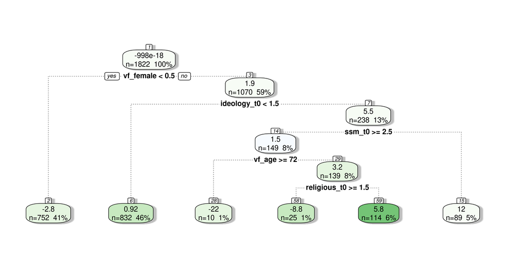

# Gradient boosting

- Each tree is grown to explain the **residual** left behind by the combination of **all previous** trees.
  - New trees are “shrunk” by some factor between $0$ and $1$

```r
library(gbm3) #install_github("gbm-developers/gbm3")
boosted_trees <- gbmt(therm_trans_t0 ~ vf_age + vf_republican + vf_democrat + vf_female + vf_hispanic +
                        religious_t0 + ssm_t0 + ideology_t0,  data = canvas_exp)
```

# Variable importance

```
                        var rel_inf
ssm_t0               ssm_t0 91.8640
ideology_t0     ideology_t0  3.8379
vf_age               vf_age  2.0290
vf_female         vf_female  1.1136
religious_t0   religious_t0  0.8673
vf_hispanic     vf_hispanic  0.1173
vf_democrat     vf_democrat  0.0881
vf_republican vf_republican  0.0829
```

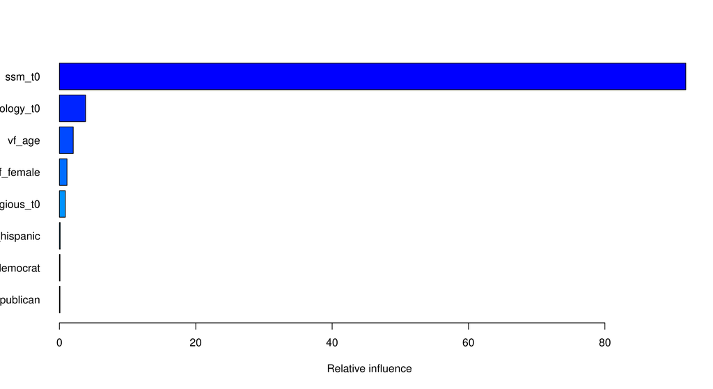

# Partial dependence plot

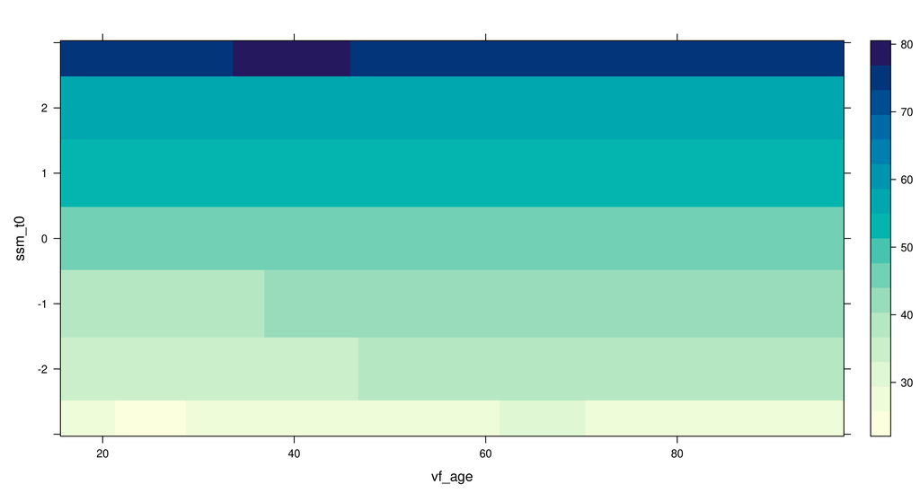

# Bayesian Additive Regression Trees (BART)

- **BART** is also a “sum-of-trees” model
  - Aggregate many individual trees into a “strong” predictor of $Y$
- But regularizes trees using a fully Bayesian outcome model

$$Y_i = \sum_{k=1}^K T_k(X_i, \theta_k) + \epsilon_i$$
$$\epsilon_{i} \sim \text{Normal}(0, \sigma^2)$$

- Place a Bayesian prior over both the tree hyperparameters $\theta_k$ (e.g. tree depth), predictions at each node ($\mu$) and outcome variance $\sigma^2$
  - Estimation via MCMC

# Causal Trees

- A common task in social science is not **prediction** but rather **description** of **heterogeneity**
  - Researchers run **randomized experiments** to identify **average** treatment effects.
- But we often want to know how the treatment effect **varies** by individuals - we want **conditional average treatment effects**
  - For which units is the effect **positive**?
  - For which units is the effect **negative**?
- Because of the **fundamental problem of causal inference**, we can’t observe individual effects directly
  - Sometimes we have a clear idea of which groups we’d like to test heterogeneity for **ex-ante**
  - But **ex-post** we’re worried about the **garden of forking paths**.
- Can we find **heterogenous treatment effects** without knowing the sub-groups in advance and without p-hacking?

# Causal Trees

- **Athey and Imbens (2016)** propose using trees to model heterogeneity.
  - Find a **partition** of the sample into subsets with **distinctive** treatment effects
- Modifies the off-the-shelf CART in two key ways:
  1. Optimizes splits for **treatment effects** (where we can’t observe the ‘ground truth’)
  2. “Honest” inference via sample splitting
- **Key intuitions**
  1. Splits for effect heterogeneity + precisely estimated treatment effects at each leaf
  2. Avoids over-fitting by estimating effects on a different sample than the one used to create the splits

# Honest inference

- We might be concerned about **over-splitting** our sample to random noise in the treatment effects.
  - The sample split criterion alone is always guaranteed to find the split that **maximizes** the difference in effects across nodes.
- **Solution** - Evaluate the treatment effects using a **separate sample**
  - “Honest” inference splits the sample randomly in two
  - The first sample is used to generate the splits for a tree
  - The second sample is used to **estimate the effects** at each node.
- Guarantees we still have unbiased inference on the treatment effects **given** a partition fit to optimize effect heterogeneity.

# Example: Effect of Canvassing

- Let’s go back to **Broockman and Kalla (2016)**
  - What’s the effect of the canvassing treatment at the first time period?

```r
canvas_exp_t1 <- canvas_exp %>% filter(!is.na(therm_trans_t1))
canvas_exp_t1 <- canvas_exp_t1 %>% mutate(therm_trans_chg = therm_trans_t1 - therm_trans_t0)
ate <- lm_robust(therm_trans_chg ~ treat_ind, data=canvas_exp_t1)
summary(ate)
```

```
Call:
lm_robust(formula = therm_trans_chg ~ treat_ind, data = canvas_exp_t1)

Standard error type:  HC2

Coefficients:
            Estimate Std. Error t value Pr(>|t|) CI Lower CI Upper  DF
(Intercept)     1.24       1.25   0.995 0.320031    -1.21     3.70 596
treat_ind       6.41       1.80   3.569 0.000387     2.89     9.94 596

Multiple R-squared:  0.0209 ,   Adjusted R-squared:  0.0193
F-statistic: 12.7 on 1 and 596 DF,  p-value: 0.000387
```

- Does this vary based on our pre-treatment covariates?

# Example: Effect of Canvassing

- If we just want a **single tree**, we can use `htetree`
  - Need to **split** our sample into training and evaluation

```r
library(htetree)
set.seed(537)
indices <- sample(1:nrow(canvas_exp_t1), nrow(canvas_exp_t1)/2)
train_canvas_t1 <- canvas_exp_t1[indices,]
eval_canvas_t1 <- canvas_exp_t1[-indices,]

trans_tree <- honest.causalTree(therm_trans_chg ~ vf_age + vf_republican + vf_democrat + vf_female + vf_hispanic +
                        religious_t0 + ssm_t0 + ideology_t0, data = train_canvas_t1,
     treatment = train_canvas_t1$treat_ind,
     est_data = eval_canvas_t1,
     est_treatment = eval_canvas_t1$treat_ind,
     split.Rule = "CT",
     cv.option = "CT", split.Honest = T, cv.Honest = T, split.Bucket = F,
                   xval = 10, cp = 0, minsize = 20, propensity = 0.5)
```

# Example: Effect of Canvassing

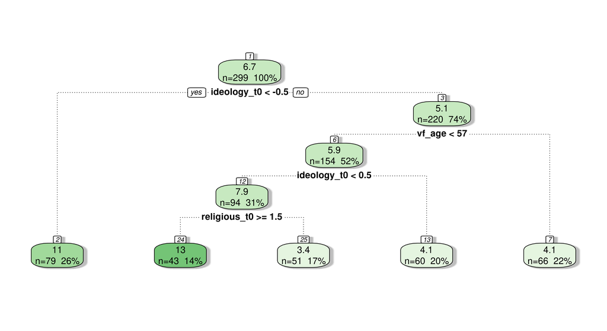

# Causal forests

- A **single** tree might still overfit and fail to accurately capture the true effect heterogeneity.
  - Unstable splits!
  - The presence of **sharp** decision boundaries means we’re unlikely to have a good estimator for the CATE $\hat{\tau}(X_i)$
- **Solution**: Do forests (**Athey and Wager (2018)**)
  - Plug in the Causal Tree algorithm into the standard random forest methodology (bagging + random subspaces)
- **Downsides**:
  - No longer have an **interpretable** set of sub-groups.
  - However, see **Huang, Tang and Kenney (2025)** for a new method for recovering these from a tree fit to the random forest predicted $\hat{\tau}(X_i)$

# Example: Effect of Canvassing

- `grf` (“generalized random forests”) implements this approach

```r
library(grf)
set.seed(53703)
trans_forest <- causal_forest(X =model.matrix( ~ vf_age + vf_republican + vf_democrat + vf_female + vf_hispanic +
                        religious_t0 + ssm_t0 + ideology_t0,  data = canvas_exp_t1),
                        Y = as.numeric(canvas_exp_t1$therm_trans_chg),
                        W = as.numeric(canvas_exp_t1$treat_ind))
print(trans_forest)
```

```
GRF forest object of type causal_forest
Number of trees: 2000
Number of training samples: 598
Variable importance:
    1     2     3     4     5     6     7     8     9
0.000 0.423 0.020 0.035 0.040 0.049 0.126 0.172 0.135
```

# Example: Effect of Canvassing

- Let’s see what the distribution of treatment effects is in-sample

```r
hist(predict(trans_forest)$predictions, xlab="Predicted CATE", ylab="Count", main = "Causal Forest CATEs")
```

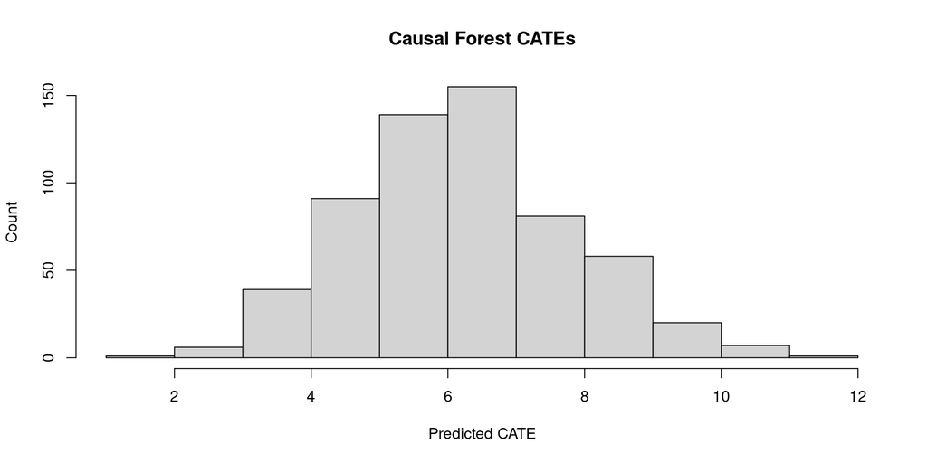

# Example: Effect of Canvassing

- We can test out the **causal distillation** method to essentially fit a conventional CART tree to the predicted effects from the causal forest!

```r
library(causalDT)
set.seed(53703)
trans_distill <- causalDT(
X =model.matrix( ~ vf_age + vf_republican + vf_democrat + vf_female + vf_hispanic +
                        religious_t0 + ssm_t0 + ideology_t0,  data = canvas_exp_t1),
                        Y = as.numeric(canvas_exp_t1$therm_trans_chg),
                        Z = as.numeric(canvas_exp_t1$treat_ind),
holdout_prop = 0.5,
teacher_model = "causal_forest",
student_model = "rpart",
rpart_control = list(cp = 0, minbucket = 20),
rpart_prune = "min"
)
```

# Distilled Effect Heterogeneity

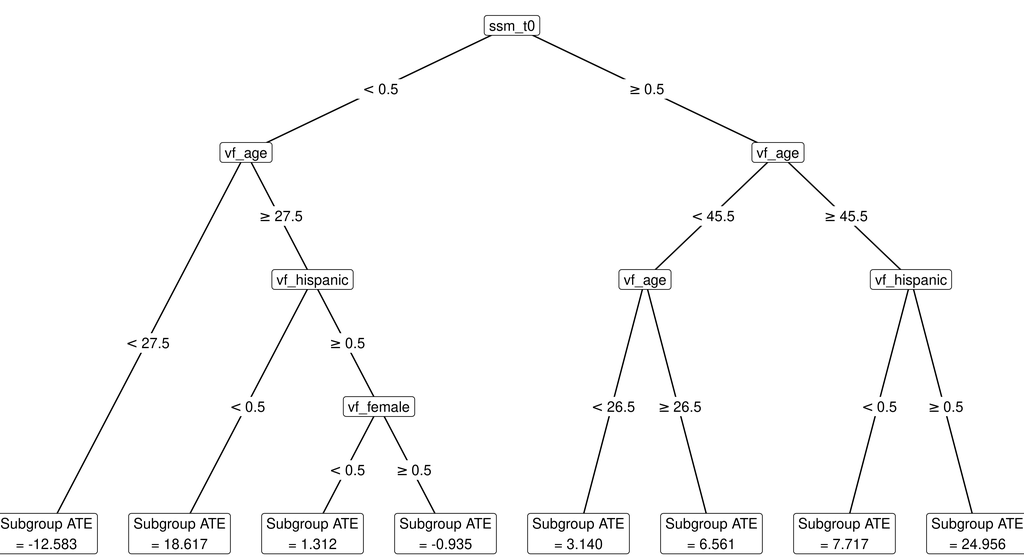

# Double Machine Learning

- In settings where we are doing **observational causal inference**, the covariates are of-interest because they are typically **confounding** factors.
  - **Conditional ignorability** - Given $X$, the treatment $D$ is assigned **as-if-random**.
- Often researchers will adjust for $X_i$ in a conventional OLS regression model

  $$Y_i = \tau D_i + \beta_0 + \beta_1X_{i1} + \beta_2X_{i2} + \dotsc + \epsilon_i$$
- But can we do this without making strong assumptions on the relationship between confounders and outcome?

  $$Y_i = \tau D_i + g(X_i) + \epsilon_i$$
- What happens if we estimate $\hat{g}(X_i)$ using a flexible machine learning method (like a random forest)?
  - Turns out our estimator of $\hat{\tau}$ will be asymptotically biased!
  - How do we solve this? **Orthogonalize the treatment**

# Double Machine Learning

- We’ll focus on the **partial linear model** setting

  $$Y_i = \tau D_i + g(X_i) + \epsilon_i$$

  $$D_i = h(X_i) + \eta_i$$
- $g()$ and $h()$ are both nuisance functions which we want to estimate via machine-learning methods.
- **Chernozukov et. al. (2018)** show that under properly constructed machine-learning estimators of $g()$ and $h()$, we can obtain an estimator of $\tau$ that is asymptotically unbiased and normal.
- **Double-machine learning** recipe:
  1. Estimate $\hat{g}(X_i)$ and generate an **outcome** prediction for each observation (using cross-fitting)
  2. Estimate $\hat{h}(X_i)$ and do the same for predicted **treatment**
  3. Create residuals $\tilde{Y_i} = Y_i - \hat{g}(X_i)$ and $\tilde{D_i} = D_i - \hat{h}(X_i)$
  4. Regress $\tilde{Y_i}$ on $\tilde{D_i}$. Estimate SEs + confidence intervals using the typical normal approximation

# Gaussian Processes

# Gaussian Processes

- As before, we want to **estimate** a conditional expectation without making strong assumptions about the shape of the functional form

  $$E[Y|X] = f(X)$$
- When we covered Bayesian GLMs, we made assumptions specifically about the shape of $f()$

  $$f(X) = g(X\beta)$$
- We searched over the space of functions defined by a **linear combination** of the inputs $X$ and the parameters $\beta$
  - Even if the sample size **grew**, we would still be estimating a **fixed** number of parameters.
  - This is what we mean when we call something a **parametric** model
- But can we be more flexible than that…

# Example: Poll averaging

- For computational reasons, we’ll focus on a **very simple** example with a small number of observations
  - 2012 Election Polls in October/November

```r
library(lubridate)
polls2012 <- read_csv("data/all_polls_2012.csv")  %>% filter(state == "--")
polls2012$end.date <- mdy(polls2012$end.date)
polls2012$obama.2way <- polls2012$obama/(polls2012$obama + polls2012$romney)
polls2012 <- polls2012 %>% filter(end.date >= ymd("2012-10-01"))
polls2012$day <- day(polls2012$end.date)
```

# Example: Poll averaging

```r
polls2012 %>% ggplot(aes(x=day, y=obama.2way)) + geom_point() + theme_minimal() + labs(x="Day", y="Obama 2-way Vote Share")
```

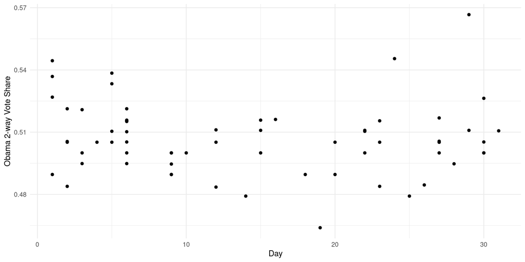

# Gaussian Processes

- We want to search over a space of **functions** $f(x)$ that is more flexible than the restricted parametric form.
  - But we need to constrain that search in some way.
  - In **Bayesian** models, we implement those constraints in the form of a **prior**.
  - Previously, we’ve specified prior distributions over parameters (e.g. $\beta \sim \text{Normal}(0, \sigma_{\beta}^2)$)
- What does it mean to define a distribution $f(x) \sim \ ?$
  - You can think about $f(x)$ as an **infinite dimensional** parameter.

# Gaussian Processes

- A **Gaussian Process** is a distribution over **functions** characterized by a **mean function** and a **covariance function**

  $$f() \sim \text{GP}(\mu, K(\cdot, \cdot))$$
- The covariance function is a **kernel** - typically the **radial basis kernel** with two hyperparameters $\sigma^2$ and $l^2$

  $$K(x, x^\prime) = Cov(f(x), f(x^\prime)) = \sigma^2\exp\bigg(-\frac{||x - x^\prime||^2}{2l^2}\bigg)$$
- If $f()$ is a **Gaussian Process**, then for any **finite number of inputs** $\mathbf{x} = x_{1}, x_{2}, x{3}, \dotsc x_{n}$, the distribution of $f()$ is **multivariate normal**

  $$\{f(x_1), f(x_2), f(x_3), \dotsc f(x_n)\} \sim \text{Normal}(\mu, \Sigma)$$
  where the elements of $\Sigma_{ij} = K(x_i, x_j)$

# Gaussian processes

- Let’s visualize what a **sample** from a Gaussian process looks like?
  - What sorts of **functions** can it represent?

```r
rbf_kernel_1d <- function(x, xprime, sigma=1, l=100){
  return((sigma^2)*exp(-(x-xprime)^2)/(2*l^2))
}
```

# Gaussian processes

```r
set.seed(53703)
mean_val <- mean(polls2012$obama.2way)
sample_dat <- data.frame(day = seq(0,31, .1))
expanded_inputs <- expand.grid(sample_dat$day, sample_dat$day)
sample_varcov <- matrix(nrow=nrow(sample_dat), ncol=nrow(sample_dat), data=rbf_kernel_1d(expanded_inputs[,1], expanded_inputs[,2]))
sample_dat$obama.2way <- MASS::mvrnorm(n=1, mu=rep(mean_val, nrow(sample_varcov)), Sigma = sample_varcov)
polls2012 %>% ggplot(aes(x=day, y=obama.2way)) + geom_point() + geom_line(data=sample_dat, lwd=2, col="grey") + theme_minimal() + labs(x="Day", y="Obama 2-way Vote Share", title = "Sample from a GP prior")
```

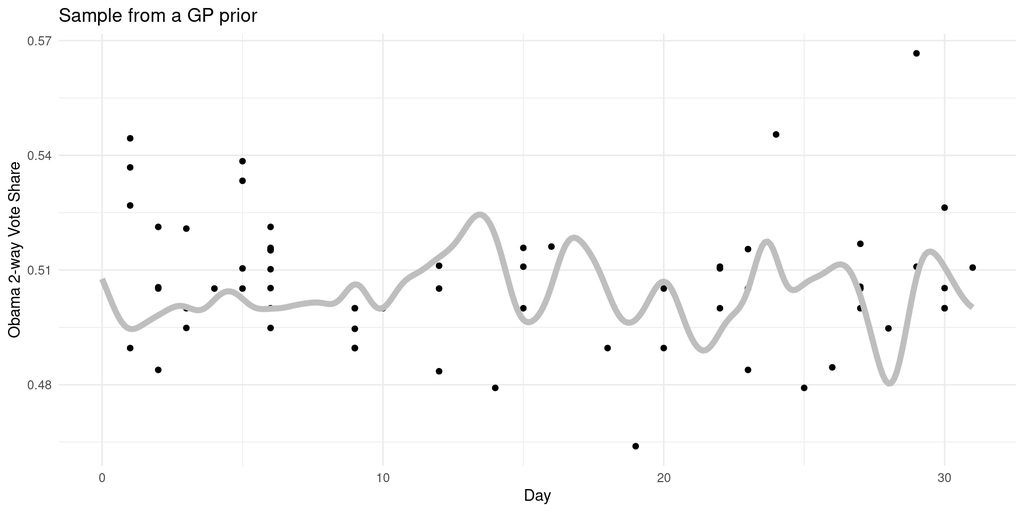

# Gaussian processes

```r
set.seed(537)
mean_val <- mean(polls2012$obama.2way)
sample_dat <- data.frame(day = seq(0,31, .1))
expanded_inputs <- expand.grid(sample_dat$day, sample_dat$day)
sample_varcov <- matrix(nrow=nrow(sample_dat), ncol=nrow(sample_dat), data=rbf_kernel_1d(expanded_inputs[,1], expanded_inputs[,2]))
sample_dat$obama.2way <- MASS::mvrnorm(n=1, mu=rep(mean_val, nrow(sample_varcov)), Sigma = sample_varcov)
polls2012 %>% ggplot(aes(x=day, y=obama.2way)) + geom_point() + geom_line(data=sample_dat, lwd=2, col="grey") + theme_minimal() + labs(x="Day", y="Obama 2-way Vote Share", title = "Another sample from a GP prior")
```

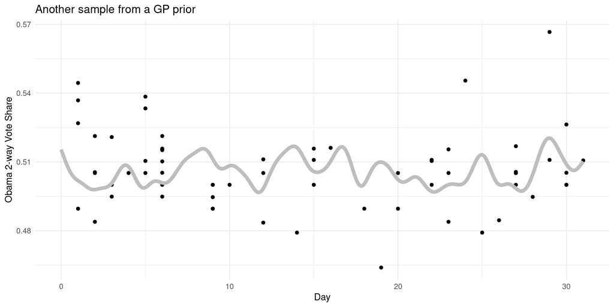

# Gaussian processes

- So the underlying functions have a particular kind of **smoothness**
  - “Close” observations have similar values of $f()$
  - Prior “wiggliness” controlled by the hyperparameters in the kernel function
  - We can put further priors on those or cross-validate them.
- Typically, we’ll use our GP to model the conditional expectation and allow the outcome to have for additional mean-zero gaussian error

  $$\{f(x_1), f(x_2), f(x_3), \dotsc f(x_n)\} \sim \text{Normal}(\mu, \Sigma + I\sigma_y^2)$$
- In a **gaussian process regression**, our goal is to do inference on the **posterior** distribution for a “new” observation $f(x_{i^\prime})$ given our input values
  - Given our prior, we know that this is going to be a **gaussian**

# Gaussian process regression

- Let’s try implementing this in R. The `mgpr` package has an easy-to-use implementation

> Varvia, P., Räty, J., Packalen, P. (2023). mgpr: An R package for multivariate Gaussian process regression SoftwareX, vol. 24, 101563. https://doi.org/10.1016/j.softx.2023.101563

```r
library(mgpr)
```

```r
gaus_process <- mgpr(datay = polls2012$obama.2way, datax = polls2012$day, polls2012, kernel = "rbf")
```

# Gaussian process regression

```r
gp_prediction <- predict(gaus_process, newdatax = matrix(seq(0, 34, by=.1)), credinter = .95)
gp_plot <- data.frame(day = seq(0, 34, by=.1), obama.2way = gp_prediction$pred[,1], lower = gp_prediction$credinter$V1_lowlim, upper = gp_prediction$credinter$V1_upplim)
polls2012 %>% ggplot(aes(x=day, y=obama.2way)) + geom_point() + geom_line(data=gp_plot, lwd=2, col="red") + geom_ribbon(aes(ymin = lower, ymax=upper), data=gp_plot, col="grey", alpha=.4) + theme_minimal() + labs(x="Day", y="Obama 2-way Vote Share", title = "Gaussian Process Regression")
```

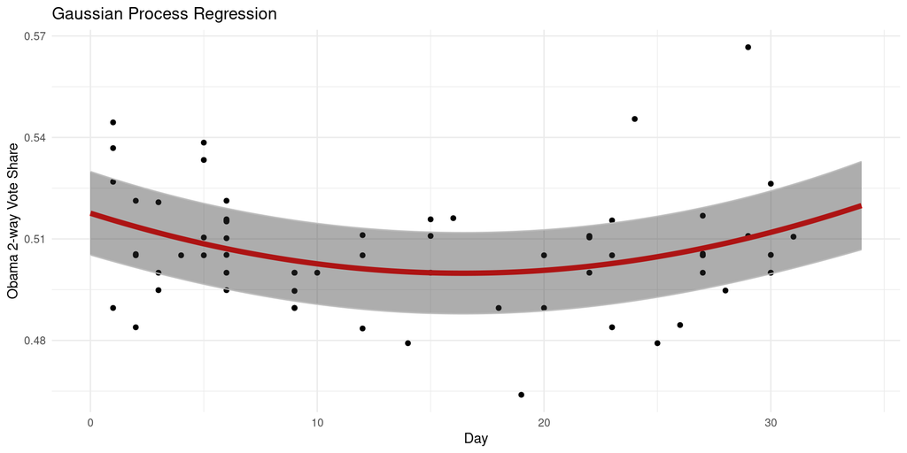

# Gaussian process regression

- What happens if we directly set the hyperparameters rather than optimize them?
  - Let’s make the “distances” between observations larger

```r
gaus_process_2 <- mgpr(datay = polls2012$obama.2way, datax = polls2012$day, polls2012, kernel = "rbf", meanf= "avg", kernpar = list(sigma = gaus_process$sigma, corlen = .5))
```

# Gaussian process regression

```r
gp_prediction <- predict(gaus_process_2, newdatax = matrix(seq(0, 34, by=.1)), credinter = .95)
gp_plot <- data.frame(day = seq(0, 34, by=.1), obama.2way = gp_prediction$pred[,1], lower = gp_prediction$credinter$V1_lowlim, upper = gp_prediction$credinter$V1_upplim)
polls2012 %>% ggplot(aes(x=day, y=obama.2way)) + geom_point() + geom_line(data=gp_plot, lwd=2, col="red") + geom_ribbon(aes(ymin = lower, ymax=upper), data=gp_plot, col="grey", alpha=.4) + theme_minimal() + labs(x="Day", y="Obama 2-way Vote Share", title = "Gaussian Process Regression - Lower covariance")
```

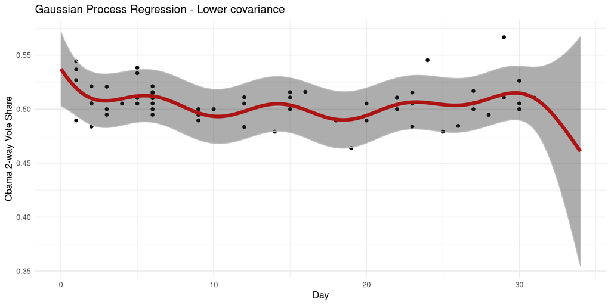